Back to Home

Documentation Center

# R Plot Collection Part 1.

a brief of visualization using the German Mortality Data 2023

## About This Document

This is my personal collection of R plotting code, using the German Mortality Data 2023 dataset as practice material. Part 1 focuses on commonly used graph types that I frequently see in scientific articles and publications - basic distributions, geographic visualizations, and comparative plots. This is purely for coding reference and learning different visualization techniques, not for scientific analysis.

> **How to read this document** - When code is **hidden** (`echo=FALSE`), treat the output as *data visualization and descriptive insight*. - When code is **shown** (`echo=TRUE`), treat the section as part of a *code example library* you can reuse.

```r
library(rio)
library(readxl)
library(tidyverse)
library(Hmisc)
library(psych)
library(lmtest)
library(ggplot2)
library(dplyr)
library(plotluck)
```

```r
csv23211 <- read_excel('statistischer-bericht-todesursachen-2120400237005.xlsx', sheet = 'csv-23211-01')

#dataset name: Anzahl nach ausgewählten Todesursachen, Altersgruppen und Geschlecht 2023
csv23212 <- read_excel('statistischer-bericht-todesursachen-2120400237005.xlsx', sheet = 'csv-23211-02')

#dataset name: je 100 000 Einwohner nach ausgewählten Todesursachen, Altersgruppen und Geschlecht 2023
csv23213 <- read_excel('statistischer-bericht-todesursachen-2120400237005.xlsx', sheet = 'csv-23211-03')
```

# 1. General Analysis

Distribution Patterns Using Scatter, Heatmap, and Trend Visualizations

This section presents an overview of mortality patterns across Germany in 2023, examining relationships between causes of death, age groups, and sex through multiple visualization techniques including scatter plots, heatmaps, point plots, and boxplots.

```r
##filt and clean key elements
csv23212$Wert <- as.numeric(csv23212$Wert)##value
csv23212$W.mi <- as.numeric(csv23213$Wert)##value per 100000
csv23212$Geschlecht <- as.factor(csv23212$Geschlecht)##sex
csv23212$Merkmal_3 <- as.factor(csv23212$Merkmal_3)##age

###typ as factor
primary_category <- sub("^(\\w{1}\\d{2}-\\w{1}\\d{2}).*", "\\1", csv23212$Merkmal_1)
csv23212s <- subset(csv23212, subset = c(csv23212$Merkmal_1 == primary_category &
                              csv23212$Merkmal_3 !='Gestorbene insgesamt' &                                      csv23212$Merkmal_1 != 'A00-U85' &
                              csv23212$Geschlecht != 'zusammen'))

csv23212s$Merkmal_1 <- as.factor(csv23212s$Merkmal_1)

###
csv23212s$Geschlecht <- droplevels(csv23212s$Geschlecht)
csv23212s$Geschlecht <- recode(csv23212s$Geschlecht, "männlich" = "male",
                               "weiblich" = "female")

### relevel of feature 3: age
csv23212s <- csv23212s %>%
  mutate(Merkmal_3 = recode(Merkmal_3,
                      "Davon im Alter unter 1 Jahren" = "-01",
                      "Davon im Alter von 1 bis unter 5 Jahren" = "01 - 05",
                      "Davon im Alter von 5 bis unter 10 Jahren" = "05 - 10",
                      "Davon im Alter von 10 bis unter 15 Jahren" = "10 - 15",
                      "Davon im Alter von 15 bis unter 20 Jahren" = "15 - 20",
                      "Davon im Alter von 20 bis unter 25 Jahren" = "20 - 25",
                      "Davon im Alter von 25 bis unter 30 Jahren" = "25 - 30",
                      "Davon im Alter von 30 bis unter 35 Jahren" = "30 - 35",
                      "Davon im Alter von 35 bis unter 40 Jahren" = "35 - 40",
                      "Davon im Alter von 40 bis unter 45 Jahren" = "40 - 45",
                      "Davon im Alter von 45 bis unter 50 Jahren" = "45 - 50",
                      "Davon im Alter von 50 bis unter 55 Jahren" = "50 - 55",
                      "Davon im Alter von 55 bis unter 60 Jahren" = "55 - 60",
                      "Davon im Alter von 60 bis unter 65 Jahren" = "60 - 65",
                      "Davon im Alter von 65 bis unter 70 Jahren" = "65 - 70",
                      "Davon im Alter von 70 bis unter 75 Jahren" = "70 - 75",
                      "Davon im Alter von 75 bis unter 80 Jahren" = "75 - 80",
                      "Davon im Alter von 80 bis unter 85 Jahren" = "80 - 85",
                      "Davon im Alter von 85 bis unter 90 Jahren" = "85 - 90",
                      "Davon im Alter von 90 Jahren und älter" = "90-",
                      "Gestorbene insgesamt" = "total deaths"))

csv23212s$Merkmal_3 <- fct_relevel(csv23212s$Merkmal_3,"-01", "01 - 05","05 - 10",
                                   "10 - 15", "15 - 20","20 - 25","25 - 30","30 - 35","35 - 40","40 - 45","45 - 50","50 - 55","55 - 60",
                                   "60 - 65","65 - 70","70 - 75","75 - 80","80 - 85","85 - 90","90-","total deaths")
```

## 1.1 Scatter Plot: Sex-based Distribution of Deaths by ICD Categories

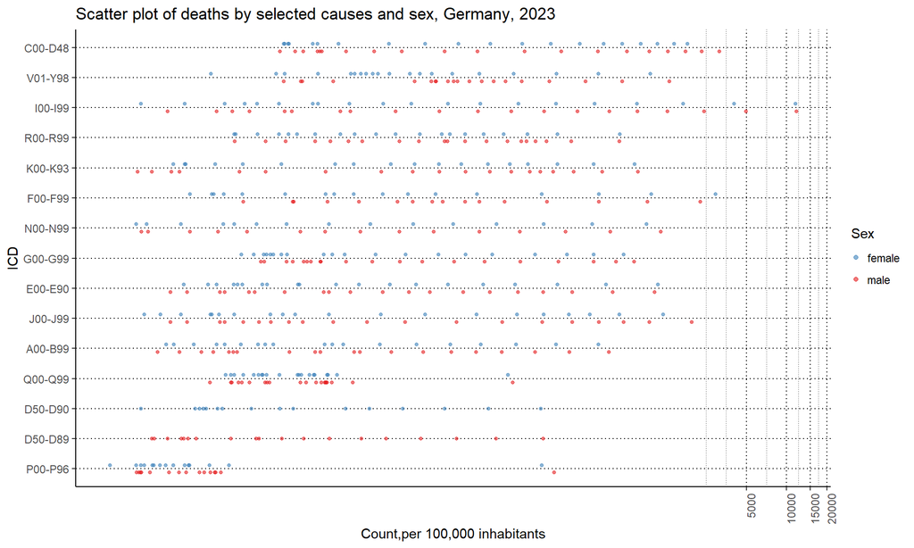

```r
#Scatter plot von value Distribution of type, facetting by sex
plotluck(csv23212s, W.mi~Merkmal_1 | Geschlecht, opts = plotluck.options(trans.log.thresh =10)) +
  theme(axis.text.x = element_text(angle = 90, hjust = 1),
    legend.position = "right") +
  labs(
    title = "Scatter plot of deaths by selected causes and sex, Germany, 2023",
    y = "Count,per 100,000 inhabitants",
    x = "ICD",
    color = "Sex"
  )
```

*Source: Destatis, Todesursachen 2023*

**Description**

This horizontal dot plot summarizes, for each ICD-10 chapter, the spread of age-specific counts along the count axis. Tight clusters indicate similar counts across age groups; wider clusters indicate greater between-age variability. Right-shifted clusters correspond to higher overall counts. Colors distinguish male and female distributions within the same ICD-10. Because age is not on an axis, the figure characterizes **within-ICD distributions** rather than age-specific peaks.

In this figure, P00–P96 shows the lowest overall counts, with the female cluster slightly further left than the male; I00–I99 exhibits a broadly even spread and the highest maximum among chapters, with a somewhat wider range for females; C00–D48 is similar to I00–I99 with the second-highest maximum, but here the male distribution spans a wider range than the female.

## 1.2 Heatmap: Age-stratified Mortality Patterns by Cause and Sex

**Logarithmically scaled heatmap displaying mortality intensity across age groups, ICD categories, and sex with gradient coloring**

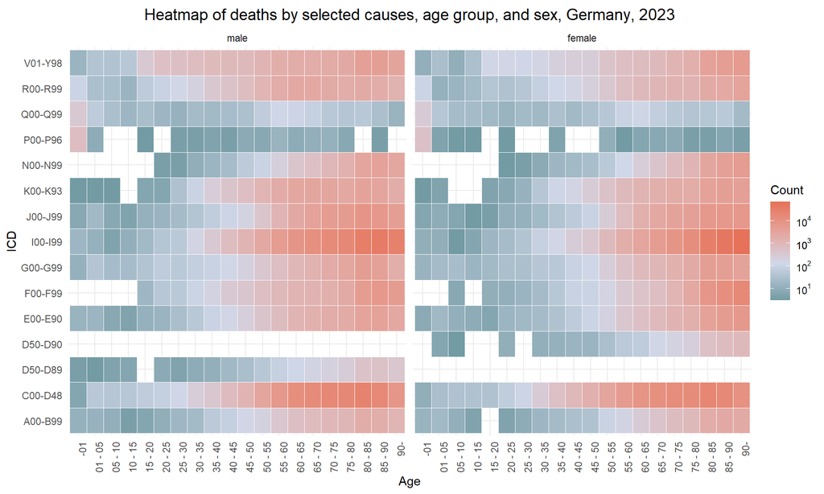

```r
#resharp of table csv23212s
strbkata <- tibble(
  'typ' = csv23212s$Merkmal_1,
  'age' = csv23212s$Merkmal_3,
  'sex' = csv23212s$Geschlecht,
  fill = csv23212s$Wert)

strbkata_clean <- strbkata %>% na.omit()
ggplot(strbkata_clean, aes(x = age, y = typ, fill = fill)) +
  geom_tile(color = "#ffffff") +
  scale_fill_gradient2(
    low = "#317479",
    mid = "#d0d7e8",
    high = "#e57259",
    midpoint = median(log10(strbkata$fill), na.rm = TRUE),
    trans = "log10",
    name = "Count",
    breaks = c(1, 10, 100, 1000, 1000, 10000),
    labels = scales::label_log()
  ) +
  facet_wrap(~ sex) +
  labs(
    title = "Heatmap of deaths by selected causes, age group, and sex, Germany, 2023",
    x = "Age",
    y = "ICD"
  ) +
  theme_minimal() +
  theme(
    plot.title = element_text(family = "Arial", size = 14, hjust = 0.5, vjust = 0.5),
    axis.text.x = element_text(angle = 90, hjust = 1),
    legend.position = "right")
```

*Source: Destatis, Todesursachen 2023*

In this figure, the horizontal axis lists age groups and the vertical axis lists ICD-10 chapters; each tile represents one age-by-ICD combination, and the fill encodes the death count. Using a teal-to-coral gradient on a log scale allows single-digit and very large values to be read on the same map. Faceting by sex places the panels side by side, providing a comprehensive view of age patterns and sex differences without displaying within-category spans explicitly. Compared with the dot plot in 1.1, this heatmap does not display the span of within-category values, but it does convey the magnitude of counts and the age-related structure of those magnitudes.

**Description**

In this figure, the heatmap summarizes, for each sex, how counts distribute across the joint space of age and ICD-10 chapter. Age groups are ordered from youngest to oldest, so left-to-right color changes indicate age-dependent change. ICD-10 chapters are categorical and appear in their standard alphanumeric order.

P00–P96 and Q00–Q99 are brightest at the youngest ages. Most ICD-10 chapters show increasing intensity with age; this trend is most pronounced for I00–I99 and C00–D48, which are brightest at older ages and already begin to intensify from the 30–40 age range. The side-by-side panels make sex differences visible. In V01–Y98, the rise in intensity begins at younger ages for males than for females.

## 1.3 Point Plot: Age Progression Trends for Each Cause of Death

**Multi-panel point plot with logarithmic y-axis showing age-related mortality trends, color-coded by sex**

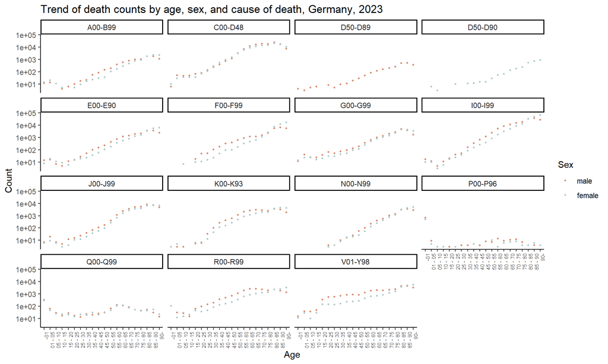

```r
strbkata_clean <- strbkata_clean %>%
  mutate(age = factor(age, levels = unique(age)))

ggplot(strbkata_clean, aes(x = age, y = fill)) +
  geom_point(aes(color = sex),size = 0.8) +
  scale_color_manual(values = c("male" = "#d78a6d", "female" = "#adc9c9")) +
  scale_y_log10() +
  labs(
    title = "Trend of death counts by age, sex, and cause of death, Germany, 2023",
    x = "Age",
    y = "Count",
    color = "Sex"
  ) +
  facet_wrap(~ typ)+
  theme_classic() +
  theme(
    axis.text.x = element_text(angle = 90, hjust = 1, size = 6.5),
    legend.position = "right"
  )
```

*Source: Destatis, Todesursachen 2023*

This figure plots age-specific death counts with age on the horizontal axis and count on the vertical axis, which is shown on a base-10 logarithmic scale. Points are coloured by sex and panels are faceted by ICD-10 chapter. The left-to-right pattern within each panel shows how counts change across ordered age groups for that chapter. Colour by sex highlights differences in level and trajectory; these visual differences can be formally evaluated with statistical tests, for example age-by-sex interaction models or paired comparisons within age groups, to assess whether they are present and how large they are.

**Description**

Each panel corresponds to one ICD-10 chapter and shows the age profile of death counts for males and females. Age groups progress from the youngest to the oldest along the horizontal axis; vertical separation at a given age indicates a sex difference in level. The logarithmic vertical scale places early-life and late-life counts in the same view and makes monotonic increases or early upturns easier to read.

P00–P96 and Q00–Q99 show a pronounced peak at the earliest ages, followed by a rapid decline that settles into a relatively stable level. By contrast, I00–I99, J00–J99, and E00–E90 dip in early life and then rise steadily with advancing age. C00–D48 and K00–K93 trace a subtle S-shaped course, with a midlife inflection before leveling at older ages. In V01–Y98, sex differences are more evident, as the male trajectory turns upward earlier than the female.

## 1.4 Boxplot: Statistical Distribution of Mortality Counts by Cause

**Logarithmic boxplot comparing death count distributions across ICD categories, stratified by sex with outlier visualization**

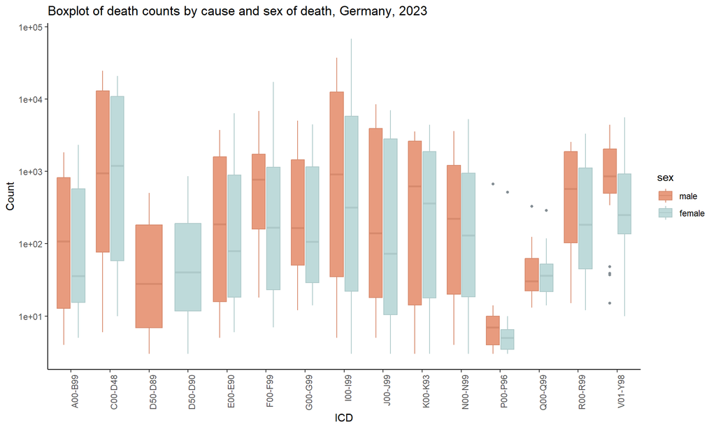

```r
ggplot(strbkata_clean, aes(x = typ, y = fill, fill = sex)) +
  geom_boxplot(aes(color = sex),
               outlier.colour = "#838d93",
               outlier.shape = 16,
               outlier.size = 1,
               notch = FALSE,
               notchwidth = 0.5) +
  scale_color_manual(values = c("male" = "#d78a6d", "female" = "#adc9c9")) +
  scale_fill_manual(values = c("male" = "#e89b7e", "female" = "#bedada")) +
  scale_y_log10() +
  labs(
    title = "Boxplot of death counts by cause and sex of death, Germany, 2023",
    x = "ICD",
    y = "Count"
  ) +
  theme_classic() +
  theme(
    axis.text.x = element_text(angle = 90, hjust = 1),
    legend.position = "right"
  )
```

*Source: Destatis, Todesursachen 2023*

This figure summarizes death counts by ICD-10 chapter and sex using boxplots. The horizontal axis lists ICD-10 chapters and the vertical axis shows Count on a base-10 logarithmic scale. For each chapter, one box per sex aggregates the **age-group** counts: the line marks the median, the box spans the interquartile range, the whiskers show the non-outlying range, and points indicate outlying age groups.

**Description**

Read each chapter vertically to compare the **typical level** and **variability across ages** for males and females. Higher medians indicate higher typical counts; wider boxes or longer whiskers indicate greater between-age dispersion; numerous outliers mark age groups that deviate strongly from the chapter’s bulk. Vertical separation between the two boxes within a chapter reflects sex differences at the chapter level.

# 2. Geographic Analysis

Regional Distribution Using Choropleth Map and State-level Heatmap

This section examines spatial patterns of mortality across German federal states, utilizing geographic visualizations to identify regional variations in specific causes of death and overall mortality patterns through maps and heatmaps.

```r
library(sf)
library(rnaturalearth)
library(rnaturalearthdata)
```

```r
# data import
deu23 <- read_excel('statistischer-bericht-todesursachen-2120400237005.xlsx', sheet = 'csv-23211-05')
deu23mi <- read_excel('statistischer-bericht-todesursachen-2120400237005.xlsx', sheet = 'csv-23211-06')

deu23$Gebiet <- as.factor(deu23$Gebiet)
deu23$Merkmal_1 <- as.factor(deu23$Merkmal_1)
deu23$Wert <- as.numeric(deu23$Wert)
deu23$W.mi <- as.numeric(deu23mi$Wert)
deu23 <- deu23 %>% filter(Merkmal_1 != 'A00-U85')

deu23oh <- subset(deu23, subset = Merkmal_1 == 'V01-V99' & Gebiet != "Deutschland")
c00 <- data.frame(Region = deu23oh$Gebiet, Anzahl = deu23oh$W.mi)

germany_map <- ne_states(country = "Germany", returnclass = "sf")
germany_map <- germany_map %>%
  dplyr::rename(Region = name)

merged_data <- dplyr::left_join(germany_map, c00, by = "Region")
```

## 2.1 Choropleth Map: Traffic Accident Mortality Rates Across German States

**Gradient-filled geographic map displaying mortality rates per 100,000 inhabitants from transport accidents (ICD V01-V99)**

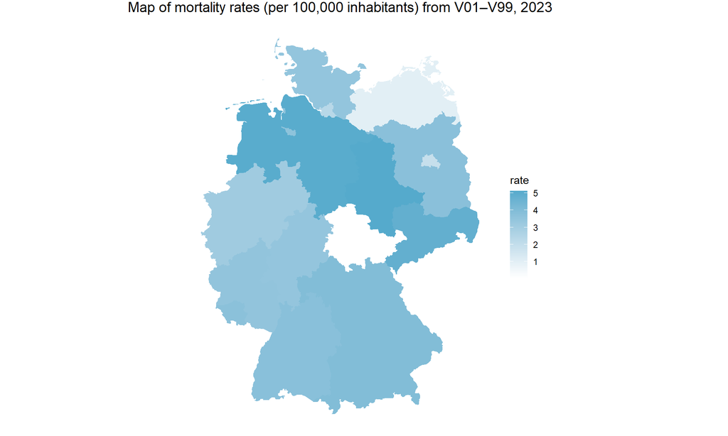

```r
# Plot
ggplot(data = merged_data) +
  geom_sf(aes(fill = Anzahl), color = NA) +
  scale_fill_viridis_c(name = "Anzahl", limits = c(min(c00$Anzahl), max(c00$Anzahl))) +
  theme_minimal() +
  labs(title = "Map of mortality rates (per 100,000 inhabitants) from V01–V99, 2023", fill = "rate") +
  theme(legend.position = "right")+
  scale_fill_gradient(low = '#ffffff', high = '#55aacc')+
  theme(
    axis.text = element_blank(),
    axis.title = element_blank(),
    panel.grid = element_blank(),
    panel.border = element_blank(),
    plot.margin = margin(0, 0, 0, 0),
    plot.title = element_text(family = "Arial", size = 14, hjust = 0.5, vjust = 0.5)
  )
```

Example1: C00-D48

Example2: F00-F99

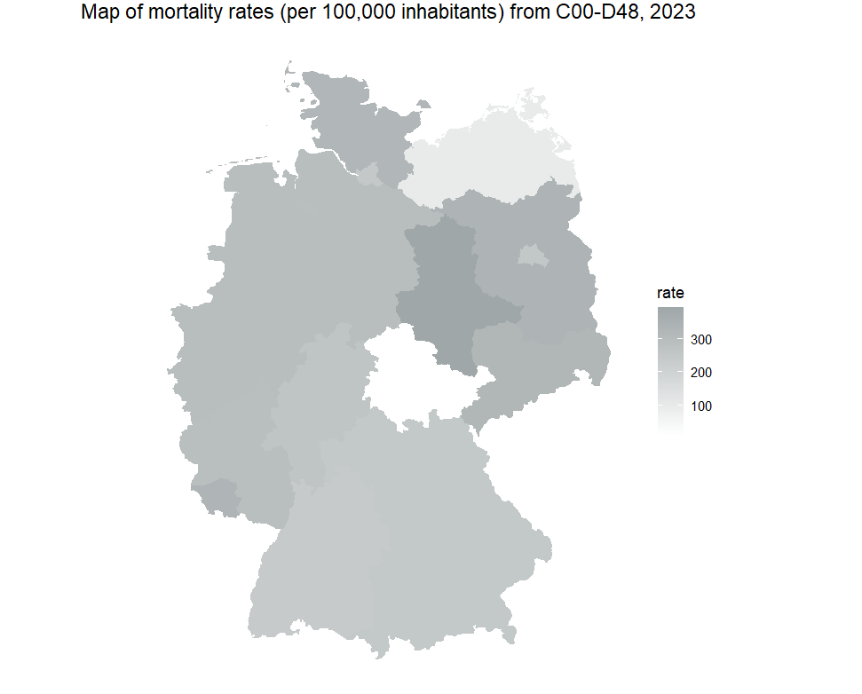

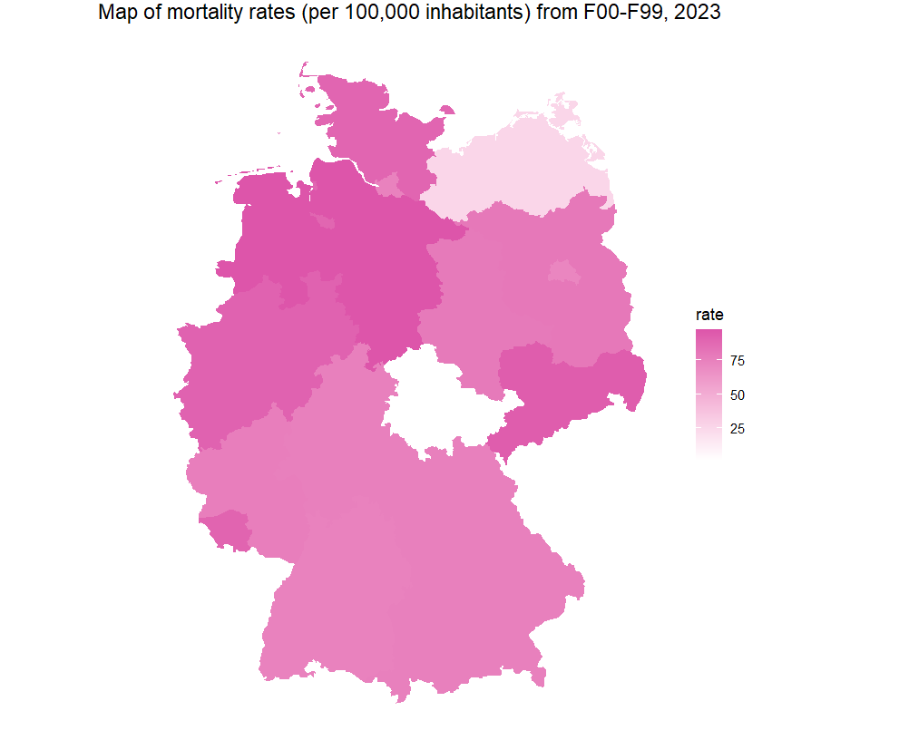

*Source: Destatis, Todesursachen 2023*

These figures are choropleths that shade German federal states to encode mortality rates per 100,000 inhabitants for a given ICD-10 chapter. There are no numeric axes because position is geographic. Each polygon is one state; the fill colour maps the rate on a continuous legend so that darker shades indicate higher mortality and lighter shades indicate lower values. Read them by comparing colour intensity across states and consulting the legend for approximate numeric rates.

**Description**

These three choropleths map mortality rates per 100,000 inhabitants by German federal state for transport accidents (V01–V99, blue), neoplasms (C00–D48, grey), and mental and behavioural disorders (F00–F99, pink). Each polygon represents one state; colour intensity is read against a continuous legend, with darker shades indicating higher rates and lighter shades lower rates, enabling state-to-state comparison on a population-standardised basis. In the blue transport-accident map (V01–V99), darker tones form a corridor across the central to mid-western states, while the north-eastern region is noticeably lighter, indicating comparatively lower rates; several other states fall between these extremes. In the grey neoplasm map (C00–D48), shading is fairly uniform overall, but parts of the central and western states show somewhat darker fills than their neighbours, suggesting modestly higher rates there. In the pink mental/behavioural map (F00–F99), the central to north-western band is predominantly darker, and Saxony in the east also stands out as darker than adjacent states; other regions tend to sit closer to the middle of the legend’s range. All three figures summarise differences at the state level; they do not display within-state variation or finer local patterns.

## 2.2 Regional Heatmap: Comprehensive State-by-Cause Mortality Matrix

**Tiled heatmap showing mortality intensity across all federal states and ICD cause categories with white-to-red gradient**

```r
reg05 <- as_tibble(read_excel('2321105.xlsx', sheet = 'Tabelle1'))
reg05 <- reg05 %>% mutate(Gebiet = as.factor(Gebiet))
reg05 <- reg05 %>% mutate(`O00-O99` = as.numeric(`O00-O99`))
datareg <- as.data.frame(reg05)
long_data <- reg05 %>%
  pivot_longer(cols = `A00-U85`:`V01-Y98`,
               names_to = "ICD",
               values_to = "Wert")

library(ggforce)

filtered_dataoh <- long_data %>% filter(ICD != 'A00-U85')
filtered_dataoh2 <- filtered_dataoh %>% filter(Gebiet != 'Deutschland')
filtered_dataoh2c <- filtered_dataoh2 %>% na.omit()
str(filtered_dataoh2)
```

```
## tibble [208 × 3] (S3: tbl_df/tbl/data.frame)
##  $ Gebiet: Factor w/ 17 levels "Baden-Württemberg",..: 1 1 1 1 1 1 1 1 1 1 ...
##  $ ICD   : chr [1:208] "C00-D48" "D50-D89" "E00-E90" "F00-F99" ...
##  $ Wert  : num [1:208] 26751 655 5247 8337 4713 ...
```

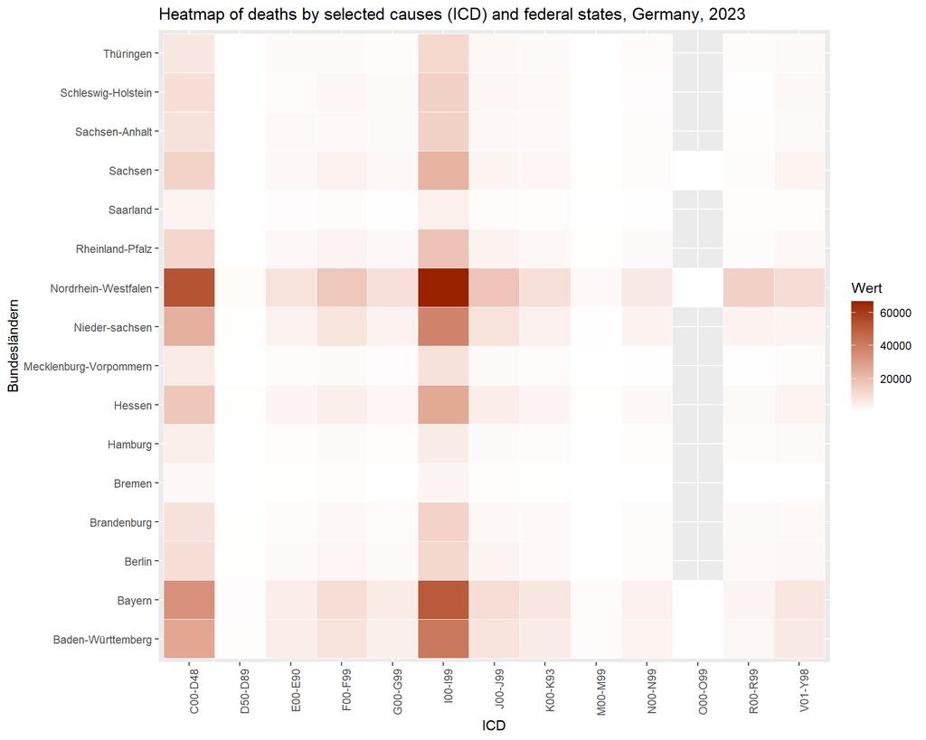

```r
ggplot(filtered_dataoh2c, aes(x=ICD, y=Gebiet, fill=Wert)) +
  geom_tile(colour="white") +
  labs(title = 'Heatmap of deaths by selected causes (ICD) and federal states, Germany, 2023',
       x = "ICD", y = "Bundesländern")+
  scale_fill_gradient(low = "#ffffff", high = '#992200')+
  theme(
    axis.text.x = element_text(angle = 90, hjust = 1),
    legend.position = "right"
  )
```

*Source: Destatis, Todesursachen 2023*

A state-by-cause heatmap that shades German federal states in rows against ICD-10 chapters in columns. Each tile represents one state × ICD combination and the fill encodes the number of deaths on a continuous light-to-dark scale (darker = more deaths). Axes are categorical: ICD-10 chapters are shown in their standard alphanumeric order along the x-axis; state names appear on the y-axis. Grey tiles denote missing or not-applicable values for the corresponding cell. This display is useful for scanning which causes contribute the largest absolute death counts in each state and for comparing column-wise or row-wise patterns at a glance.

**Description**

Counts concentrate in a few columns across most states: I00–I99 and C00–D48 show the darkest bands, indicating the largest absolute contributions to mortality. Large, populous states such as Nordrhein-Westfalen and Bayern display darker tiles across several causes, whereas smaller states (for example Bremen, Saarland) are lighter overall. The column O00–O99 appears greyed, reflecting missing or not-applicable entries in this extract. Because the metric is absolute counts, the heatmap reflects population size as well as cause structure; for risk comparison across states, a rate-based version (per 100,000) would be more appropriate.

# 3. Berlin-focused Analysis

Local Patterns Using Bar Chart and Donut Chart Visualizations

This section provides detailed analysis of mortality patterns specifically in Berlin, comparing local rates to national averages through bar charts and examining the proportional distribution of causes through a donut chart visualization.

```r
icd_codes <- deu23$Merkmal_1
icd_first_letter <- substr(icd_codes, 1, 1)
unique_letters <- unique(icd_first_letter)
deu23$icd.k <- factor(icd_first_letter,
                      levels = c("A", "B", "C", "D", "E", "F", "G",
                                 "I", "J", "K", "L", "M", "N", "O", "P",
                                 "Q", "R", "S", "T", "U", "V", "W", "X", "Y"),
                      labels = c("Infectious & Parasitic",
                                 "Infectious & Parasitic",
                                 "Neoplasms",
                                 "Blood Disorders",
                                 "Endocrine & Metabolic",
                                 "Mental & Behavioral",
                                 "Nervous System",
                                 "Circulatory System",
                                 "Respiratory System",
                                 "Digestive System",
                                 "Skin & Subcutaneous",
                                 "Musculoskeletal",
                                 "Genitourinary System",
                                 "Pregnancy & Childbirth",
                                 "Perinatal Conditions",
                                 "Congenital Malformations",
                                 "Symptoms & Signs",
                                 "Injury & Poisoning",
                                 "Injury & Poisoning",
                                 "Special Codes",
                                 "External Causes",
                                 "External Causes",
                                 "External Causes",
                                 "External Causes"))

ber23 <- subset(deu23, subset = Gebiet == "Berlin")
ber23df <- data.frame(Typ = ber23$Merkmal_1, Anzahl = ber23$W.mi, icd = ber23$icd.k)

d23 <- subset(deu23, subset = Gebiet == "Deutschland")
d23df <- data.frame(Typ = d23$Merkmal_1, Anzahl = d23$W.mi, icd = d23$icd.k)

ber23df$Anzahld <-d23df$Anzahl
```

## 3.1 Comparative Bar Chart: Berlin vs. National Mortality Rates

**Logarithmic bar chart displaying Berlin’s mortality rates by ICD category, color-coded by disease class, with national comparison points and annotated values**

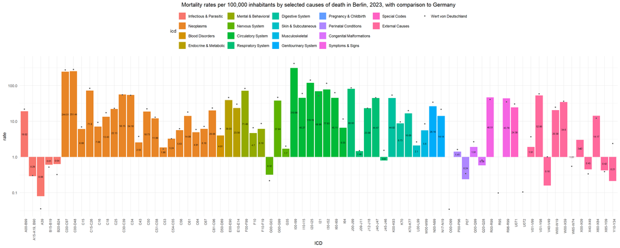

```r
ggplot(ber23df, aes(x = Typ, y = Anzahl, fill = icd)) +
  geom_bar(stat = "identity", position = "dodge") +
  geom_point(aes(y = Anzahld, color ="Anzahld"),size = 1,shape = 21, fill = "#555555")+
  scale_color_manual(
    name = "",
  values = c("Anzahld" = "#555555"), labels = c( "Anzahld" = "Wert von Deutschland")) +
  scale_y_log10() +
  theme_minimal() +
  labs(title = "Mortality rates per 100,000 inhabitants by selected causes of death in Berlin, 2023, with comparison to Germany",
       x = "ICD",
       y = "rate"
       ) +
  geom_text(aes(label = round(Anzahl,2)),
            position = position_stack(vjust = 0.5),
            size = 2,
            color = "black") +
        theme(axis.text.x = element_text(angle = 90 ,hjust = 1, size = 8),
        plot.title = element_text(hjust = 0.5),legend.position = "top")
```

*Source: Destatis, Todesursachen 2023*

This figure displays mortality rates per 100,000 inhabitants by selected causes of death in Berlin, 2023, with comparison to Germany. The vertical axis shows the mortality rate on a log10 scale, and the horizontal axis lists specific ICD-10 codes. Bars are colored by ICD-10 chapter category, with Berlin rates shown as colored bars and Germany rates indicated by black dots for comparison.

**Description**

Berlin’s rates generally align closely with German national averages across most categories, though minor deviations appear in specific causes within External Causes and Symptoms & Signs categories.

## 3.2 Donut Chart: Proportional Distribution of Leading Causes in Berlin

**Polar coordinate donut chart showing proportional breakdown of the top 12 causes of death, with radial labels displaying counts and percentages**

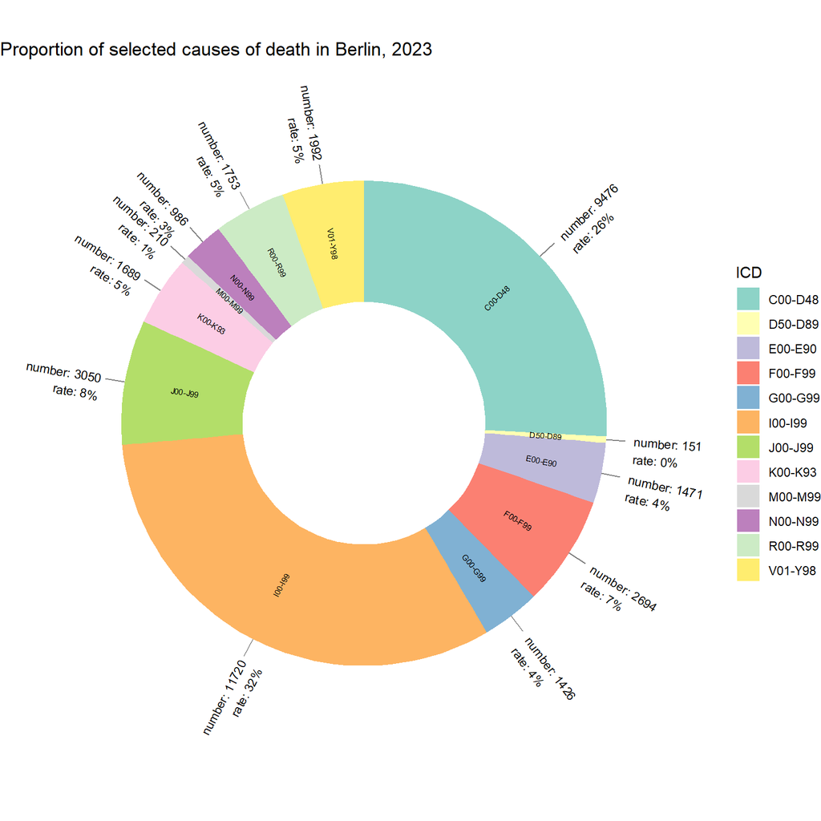

```r
filtered_dataoh2ber <- filtered_dataoh %>% filter(Gebiet == 'Berlin')
ber23dfw <- data.frame(Typ = filtered_dataoh2ber$ICD, Anzahl = filtered_dataoh2ber$Wert)
ber23dffwnr <- ber23dfw[!is.na(ber23dfw$Anzahl),]
ber23dffwnr$pre <- ber23dffwnr$Anzahl /sum(ber23dffwnr$Anzahl)

#cumulative percentages (top of each rectangle)
ber23dffwnr$ymax <- cumsum(ber23dffwnr$pre)
#bottom of each rectangle
ber23dffwnr$ymin <- c(0, head(ber23dffwnr$ymax, n=-1))

#label position
ber23dffwnr$labelPosition <- (ber23dffwnr$ymax + ber23dffwnr$ymin) / 2
#label text
ber23dffwnr$label <- paste0("\n number: ", ber23dffwnr$Anzahl,"\n rate: ",100*round(ber23dffwnr$pre,2),'%')

ber23dffwnr <- ber23dffwnr %>%
  mutate(
    mid = (ymax + ymin) / 2,
    angle = 90 - 360 * mid / max(ymax),
    hjust = ifelse(angle < -90, 1, 0),
    angle = ifelse(angle < -90, angle + 180, angle)
  )

ggplot(ber23dffwnr, aes(ymax=ymax, ymin=ymin, xmax=5, xmin=2.5, fill=Typ)) +
  geom_rect() +
  scale_fill_brewer(palette='Set3') +
  geom_segment(
    data = ber23dffwnr %>%
      dplyr::arrange(desc(pre)) %>%
      dplyr::slice_head(n = 12),
    aes(x = 5, xend = 5.4, y = mid, yend = mid),
    inherit.aes = FALSE,
    color = "grey50"
  ) +
  geom_text(
    data = ber23dffwnr %>%
      dplyr::arrange(desc(pre)) %>%
      dplyr::slice_head(n = 12),
    aes(x = 5.5, y = mid, label = label, hjust = hjust,angle = angle),
    inherit.aes = FALSE,
    size = 3
  )+
  geom_text(
    data = ber23dffwnr %>%
      dplyr::arrange(desc(pre)) %>%
      dplyr::slice_head(n = 12),
    aes(x = (5 + 2.5) / 2,
        y = (ymin + ymax) / 2,
        label = Typ,angle = angle),
    inherit.aes = FALSE,
    size = 2,
    color = "black"
  )+
  coord_polar(theta="y") +
  xlim(c(0, 6)) +
  theme_void() +
  labs(title = 'Proportion of selected causes of death in Berlin, 2023', fill = "ICD")
```

*Source: Destatis, Todesursachen 2023*

This donut chart displays the proportion of selected causes of death in Berlin, 2023, by ICD-10 chapter. Donut charts show part-to-whole relationships through circular segments, where arc length represents each category’s proportion of the total. Each segment is labeled with the ICD-10 code range, absolute count, and percentage.

**Reference**

Statistisches Bundesamt (Destatis). n.d. “Todesursachen in Deutschland 2023: Statistischer Bericht.” Accessed October 1, 2025. [https://www.destatis.de/DE/Themen/Gesellschaft-Umwelt/Gesundheit/Todesursachen/\_inhalt.html](https://www.destatis.de/DE/Themen/Gesellschaft-Umwelt/Gesundheit/Todesursachen/_inhalt.html).